```python
import pandas as pd
import numpy as np
```

# Q-2 Observations on the shape of data,data types of all the attributes,missing value detection,statistical summary

```python
df = pd.read_csv('netflix.csv')
df
```

|  | show_id | type | title | director | cast | country | date_added | release_year | rating | duration | listed_in | description |
| --- | --- | --- | --- | --- | --- | --- | --- | --- | --- | --- | --- | --- |
| 0 | s1 | Movie | Dick Johnson Is Dead | Kirsten Johnson | NaN | United States | September 25, 2021 | 2020 | PG-13 | 90 min | Documentaries | As her father nears the end of his life, filmm... |
| 1 | s2 | TV Show | Blood & Water | NaN | Ama Qamata, Khosi Ngema, Gail Mabalane, Thaban... | South Africa | September 24, 2021 | 2021 | TV-MA | 2 Seasons | International TV Shows, TV Dramas, TV Mysteries | After crossing paths at a party, a Cape Town t... |
| 2 | s3 | TV Show | Ganglands | Julien Leclercq | Sami Bouajila, Tracy Gotoas, Samuel Jouy, Nabi... | NaN | September 24, 2021 | 2021 | TV-MA | 1 Season | Crime TV Shows, International TV Shows, TV Act... | To protect his family from a powerful drug lor... |
| 3 | s4 | TV Show | Jailbirds New Orleans | NaN | NaN | NaN | September 24, 2021 | 2021 | TV-MA | 1 Season | Docuseries, Reality TV | Feuds, flirtations and toilet talk go down amo... |
| 4 | s5 | TV Show | Kota Factory | NaN | Mayur More, Jitendra Kumar, Ranjan Raj, Alam K... | India | September 24, 2021 | 2021 | TV-MA | 2 Seasons | International TV Shows, Romantic TV Shows, TV ... | In a city of coaching centers known to train I... |
| ... | ... | ... | ... | ... | ... | ... | ... | ... | ... | ... | ... | ... |
| 8802 | s8803 | Movie | Zodiac | David Fincher | Mark Ruffalo, Jake Gyllenhaal, Robert Downey J... | United States | November 20, 2019 | 2007 | R | 158 min | Cult Movies, Dramas, Thrillers | A political cartoonist, a crime reporter and a... |
| 8803 | s8804 | TV Show | Zombie Dumb | NaN | NaN | NaN | July 1, 2019 | 2018 | TV-Y7 | 2 Seasons | Kids' TV, Korean TV Shows, TV Comedies | While living alone in a spooky town, a young g... |
| 8804 | s8805 | Movie | Zombieland | Ruben Fleischer | Jesse Eisenberg, Woody Harrelson, Emma Stone, ... | United States | November 1, 2019 | 2009 | R | 88 min | Comedies, Horror Movies | Looking to survive in a world taken over by zo... |
| 8805 | s8806 | Movie | Zoom | Peter Hewitt | Tim Allen, Courteney Cox, Chevy Chase, Kate Ma... | United States | January 11, 2020 | 2006 | PG | 88 min | Children & Family Movies, Comedies | Dragged from civilian life, a former superhero... |
| 8806 | s8807 | Movie | Zubaan | Mozez Singh | Vicky Kaushal, Sarah-Jane Dias, Raaghav Chanan... | India | March 2, 2019 | 2015 | TV-14 | 111 min | Dramas, International Movies, Music & Musicals | A scrappy but poor boy worms his way into a ty... |

8807 rows × 12 columns

Above df includes movies and TV show combined

```python
#shape of data
df.shape
```

```
(8807, 12)
```

This means dataframe has 8807 unique movies/Tvshows release on Netflix and 12 column attributes

```python
len(df)
```

```
8807
```

```python
#data types of all the attributes
df.info()
```

```
<class 'pandas.core.frame.DataFrame'>
RangeIndex: 8807 entries, 0 to 8806
Data columns (total 12 columns):
 #   Column        Non-Null Count  Dtype
---  ------        --------------  -----
 0   show_id       8807 non-null   object
 1   type          8807 non-null   object
 2   title         8807 non-null   object
 3   director      6173 non-null   object
 4   cast          7982 non-null   object
 5   country       7976 non-null   object
 6   date_added    8797 non-null   object
 7   release_year  8807 non-null   int64
 8   rating        8803 non-null   object
 9   duration      8804 non-null   object
 10  listed_in     8807 non-null   object
 11  description   8807 non-null   object
dtypes: int64(1), object(11)
memory usage: 825.8+ KB
```

```python
#missing value detection
np.round((df.isna().sum()/len(df))*100,2)
```

|  | 0 |
| --- | --- |
| show_id | 0.00 |
| type | 0.00 |
| title | 0.00 |
| director | 29.91 |
| cast | 9.37 |
| country | 9.44 |
| date_added | 0.11 |
| release_year | 0.00 |
| rating | 0.05 |
| duration | 0.03 |
| listed_in | 0.00 |
| description | 0.00 |

**dtype:** float64

Significant missing values i.e 29% in the directors columns and in cast and country column approx 10% missing values.

```python
#statistical summary
df.describe()
```

|  | release_year |
| --- | --- |
| count | 8807.000000 |
| mean | 2014.180198 |
| std | 8.819312 |
| min | 1925.000000 |
| 25% | 2013.000000 |
| 50% | 2017.000000 |
| 75% | 2019.000000 |
| max | 2021.000000 |

Above df include statistical summary.

```python
df.describe(include = object)
```

|  | show_id | type | title | director | cast | country | date_added | rating | duration | listed_in | description |
| --- | --- | --- | --- | --- | --- | --- | --- | --- | --- | --- | --- |
| count | 8807 | 8807 | 8807 | 6173 | 7982 | 7976 | 8797 | 8803 | 8804 | 8807 | 8807 |
| unique | 8807 | 2 | 8807 | 4528 | 7692 | 748 | 1767 | 17 | 220 | 514 | 8775 |
| top | s1 | Movie | Dick Johnson Is Dead | Rajiv Chilaka | David Attenborough | United States | January 1, 2020 | TV-MA | 1 Season | Dramas, International Movies | Paranormal activity at a lush, abandoned prope... |
| freq | 1 | 6131 | 1 | 19 | 19 | 2818 | 109 | 3207 | 1793 | 362 | 4 |

Above df includes non-continous data also

```python
df.index
```

```
RangeIndex(start=0, stop=8807, step=1)
```

```python
df.head(5)
```

|  | show_id | type | title | director | cast | country | date_added | release_year | rating | duration | listed_in | description |
| --- | --- | --- | --- | --- | --- | --- | --- | --- | --- | --- | --- | --- |
| 0 | s1 | Movie | Dick Johnson Is Dead | Kirsten Johnson | NaN | United States | September 25, 2021 | 2020 | PG-13 | 90 min | Documentaries | As her father nears the end of his life, filmm... |
| 1 | s2 | TV Show | Blood & Water | NaN | Ama Qamata, Khosi Ngema, Gail Mabalane, Thaban... | South Africa | September 24, 2021 | 2021 | TV-MA | 2 Seasons | International TV Shows, TV Dramas, TV Mysteries | After crossing paths at a party, a Cape Town t... |
| 2 | s3 | TV Show | Ganglands | Julien Leclercq | Sami Bouajila, Tracy Gotoas, Samuel Jouy, Nabi... | NaN | September 24, 2021 | 2021 | TV-MA | 1 Season | Crime TV Shows, International TV Shows, TV Act... | To protect his family from a powerful drug lor... |
| 3 | s4 | TV Show | Jailbirds New Orleans | NaN | NaN | NaN | September 24, 2021 | 2021 | TV-MA | 1 Season | Docuseries, Reality TV | Feuds, flirtations and toilet talk go down amo... |
| 4 | s5 | TV Show | Kota Factory | NaN | Mayur More, Jitendra Kumar, Ranjan Raj, Alam K... | India | September 24, 2021 | 2021 | TV-MA | 2 Seasons | International TV Shows, Romantic TV Shows, TV ... | In a city of coaching centers known to train I... |

# Q-1 Defining Problem Statement and Analysing basic metrics

Q-1a) Comparison of tv shows vs. movies in terms of proportion?

```python
df['type'].value_counts(normalize = True)*100
```

| type | proportion |
| --- | --- |
| Movie | 69.615079 |
| TV Show | 30.384921 |

**dtype:** float64

Insights

Q-1b) Show the dataframew of movies only?

```python
df_movies = df.loc[df['type']=='Movie']
```

Insights

- These are movies list dataframe

Q-1c) Show the dataframe of TV Shows only?

```python
df_TV = df.loc[df['type']=='TV Show']
```

Insights

- These are TVshow list dataframe

Q-1d) Show the missing value in movies dataframe in %?

```python
(np.round(df_movies.isna().sum()/len(df_movies),2))*100
```

|  | 0 |
| --- | --- |
| show_id | 0.0 |
| type | 0.0 |
| title | 0.0 |
| director | 3.0 |
| cast | 8.0 |
| country | 7.0 |
| date_added | 0.0 |
| release_year | 0.0 |
| rating | 0.0 |
| duration | 0.0 |
| listed_in | 0.0 |
| description | 0.0 |

**dtype:** float64

Insights

- % of missing values in column of cast and country is around 7-8% in Movies dataframe.

Q-1e) Show the missing value in Tv Show dataframe in %?

```python
(np.round(df_TV.isna().sum()/len(df_TV),2))*100
```

|  | 0 |
| --- | --- |
| show_id | 0.0 |
| type | 0.0 |
| title | 0.0 |
| director | 91.0 |
| cast | 13.0 |
| country | 15.0 |
| date_added | 0.0 |
| release_year | 0.0 |
| rating | 0.0 |
| duration | 0.0 |
| listed_in | 0.0 |
| description | 0.0 |

**dtype:** float64

Insights

- % of missing values in TV show dataframe
- Majority of missing values are from director column

Q-1f) Show the country contribution for movies and TVshow on Netflix?

```python
df_movies_explode= df_movies.copy()
```

```python
df_movies_explode['country'] = df_movies_explode['country'].str.split(',')
```

```python
df_movies_explode = df_movies_explode.explode('country')
```

```python
df_movies_explode['country'] = df_movies_explode['country'].str.strip()
```

```python
df_TV_explode = df_TV.copy()
```

```python
df_TV_explode['country'] = df_TV_explode['country'].dropna().apply(lambda x:x.split(','))
```

```python
df_TV_explode = df_TV_explode.explode('country')
```

```python
df_movies_explode
#final
```

|  | show_id | type | title | director | cast | country | date_added | release_year | rating | duration | listed_in | description |
| --- | --- | --- | --- | --- | --- | --- | --- | --- | --- | --- | --- | --- |
| 0 | s1 | Movie | Dick Johnson Is Dead | Kirsten Johnson | NaN | United States | September 25, 2021 | 2020 | PG-13 | 90 min | Documentaries | As her father nears the end of his life, filmm... |
| 6 | s7 | Movie | My Little Pony: A New Generation | Robert Cullen, José Luis Ucha | Vanessa Hudgens, Kimiko Glenn, James Marsden, ... | NaN | September 24, 2021 | 2021 | PG | 91 min | Children & Family Movies | Equestria's divided. But a bright-eyed hero be... |
| 7 | s8 | Movie | Sankofa | Haile Gerima | Kofi Ghanaba, Oyafunmike Ogunlano, Alexandra D... | United States | September 24, 2021 | 1993 | TV-MA | 125 min | Dramas, Independent Movies, International Movies | On a photo shoot in Ghana, an American model s... |
| 7 | s8 | Movie | Sankofa | Haile Gerima | Kofi Ghanaba, Oyafunmike Ogunlano, Alexandra D... | Ghana | September 24, 2021 | 1993 | TV-MA | 125 min | Dramas, Independent Movies, International Movies | On a photo shoot in Ghana, an American model s... |
| 7 | s8 | Movie | Sankofa | Haile Gerima | Kofi Ghanaba, Oyafunmike Ogunlano, Alexandra D... | Burkina Faso | September 24, 2021 | 1993 | TV-MA | 125 min | Dramas, Independent Movies, International Movies | On a photo shoot in Ghana, an American model s... |
| ... | ... | ... | ... | ... | ... | ... | ... | ... | ... | ... | ... | ... |
| 8801 | s8802 | Movie | Zinzana | Majid Al Ansari | Ali Suliman, Saleh Bakri, Yasa, Ali Al-Jabri, ... | Jordan | March 9, 2016 | 2015 | TV-MA | 96 min | Dramas, International Movies, Thrillers | Recovering alcoholic Talal wakes up inside a s... |
| 8802 | s8803 | Movie | Zodiac | David Fincher | Mark Ruffalo, Jake Gyllenhaal, Robert Downey J... | United States | November 20, 2019 | 2007 | R | 158 min | Cult Movies, Dramas, Thrillers | A political cartoonist, a crime reporter and a... |
| 8804 | s8805 | Movie | Zombieland | Ruben Fleischer | Jesse Eisenberg, Woody Harrelson, Emma Stone, ... | United States | November 1, 2019 | 2009 | R | 88 min | Comedies, Horror Movies | Looking to survive in a world taken over by zo... |
| 8805 | s8806 | Movie | Zoom | Peter Hewitt | Tim Allen, Courteney Cox, Chevy Chase, Kate Ma... | United States | January 11, 2020 | 2006 | PG | 88 min | Children & Family Movies, Comedies | Dragged from civilian life, a former superhero... |
| 8806 | s8807 | Movie | Zubaan | Mozez Singh | Vicky Kaushal, Sarah-Jane Dias, Raaghav Chanan... | India | March 2, 2019 | 2015 | TV-14 | 111 min | Dramas, International Movies, Music & Musicals | A scrappy but poor boy worms his way into a ty... |

7819 rows × 12 columns

```python
df_TV_explode
#final
```

|  | show_id | type | title | director | cast | country | date_added | release_year | rating | duration | listed_in | description |
| --- | --- | --- | --- | --- | --- | --- | --- | --- | --- | --- | --- | --- |
| 1 | s2 | TV Show | Blood & Water | NaN | Ama Qamata, Khosi Ngema, Gail Mabalane, Thaban... | South Africa | September 24, 2021 | 2021 | TV-MA | 2 Seasons | International TV Shows, TV Dramas, TV Mysteries | After crossing paths at a party, a Cape Town t... |
| 2 | s3 | TV Show | Ganglands | Julien Leclercq | Sami Bouajila, Tracy Gotoas, Samuel Jouy, Nabi... | NaN | September 24, 2021 | 2021 | TV-MA | 1 Season | Crime TV Shows, International TV Shows, TV Act... | To protect his family from a powerful drug lor... |
| 3 | s4 | TV Show | Jailbirds New Orleans | NaN | NaN | NaN | September 24, 2021 | 2021 | TV-MA | 1 Season | Docuseries, Reality TV | Feuds, flirtations and toilet talk go down amo... |
| 4 | s5 | TV Show | Kota Factory | NaN | Mayur More, Jitendra Kumar, Ranjan Raj, Alam K... | India | September 24, 2021 | 2021 | TV-MA | 2 Seasons | International TV Shows, Romantic TV Shows, TV ... | In a city of coaching centers known to train I... |
| 5 | s6 | TV Show | Midnight Mass | Mike Flanagan | Kate Siegel, Zach Gilford, Hamish Linklater, H... | NaN | September 24, 2021 | 2021 | TV-MA | 1 Season | TV Dramas, TV Horror, TV Mysteries | The arrival of a charismatic young priest brin... |
| ... | ... | ... | ... | ... | ... | ... | ... | ... | ... | ... | ... | ... |
| 8797 | s8798 | TV Show | Zak Storm | NaN | Michael Johnston, Jessica Gee-George, Christin... | France | September 13, 2018 | 2016 | TV-Y7 | 3 Seasons | Kids' TV | Teen surfer Zak Storm is mysteriously transpor... |
| 8797 | s8798 | TV Show | Zak Storm | NaN | Michael Johnston, Jessica Gee-George, Christin... | South Korea | September 13, 2018 | 2016 | TV-Y7 | 3 Seasons | Kids' TV | Teen surfer Zak Storm is mysteriously transpor... |
| 8797 | s8798 | TV Show | Zak Storm | NaN | Michael Johnston, Jessica Gee-George, Christin... | Indonesia | September 13, 2018 | 2016 | TV-Y7 | 3 Seasons | Kids' TV | Teen surfer Zak Storm is mysteriously transpor... |
| 8800 | s8801 | TV Show | Zindagi Gulzar Hai | NaN | Sanam Saeed, Fawad Khan, Ayesha Omer, Mehreen ... | Pakistan | December 15, 2016 | 2012 | TV-PG | 1 Season | International TV Shows, Romantic TV Shows, TV ... | Strong-willed, middle-class Kashaf and carefre... |
| 8803 | s8804 | TV Show | Zombie Dumb | NaN | NaN | NaN | July 1, 2019 | 2018 | TV-Y7 | 2 Seasons | Kids' TV, Korean TV Shows, TV Comedies | While living alone in a spooky town, a young g... |

3031 rows × 12 columns

```python
df_TV_explode['country'].value_counts().head(10)
```

| country | count |
| --- | --- |
| United States | 847 |
| United Kingdom | 246 |
| Japan | 174 |
| South Korea | 164 |
| United States | 91 |
| Canada | 84 |
| India | 81 |
| Taiwan | 70 |
| France | 64 |
| Australia | 56 |

**dtype:** int64

```python
df_movies_explode['country'].value_counts().head(10)
```

| country | count |
| --- | --- |
| United States | 2752 |
| India | 962 |
| United Kingdom | 534 |
| Canada | 319 |
| France | 303 |
| Germany | 182 |
| Spain | 171 |
| Japan | 119 |
| China | 114 |
| Mexico | 111 |

**dtype:** int64

Insights

- Majority of movies were released in USA
- USA and India are major markets in movies movies for netflix
- Majority of tv shows were released in USA.
- USA, UK are major markets for netflix in terms of TV Shows

```python
import matplotlib.pyplot as plt
import seaborn as sns
```

Modifying dataframe of movies for better analysis and insights.

- Adding two columns 'duration_time and date_added(as datetime format) for better visualisation and analysis.

```python
df_movies['duration_time'] =df_movies['duration'].dropna().apply(lambda x:x[0:-4]).astype('int')
```

```python
df_movies['date_added_datetime'] = pd.to_datetime(df_movies['date_added'])
```

```python
df_movies.info()
```

```
<class 'pandas.core.frame.DataFrame'>
Index: 6131 entries, 0 to 8806
Data columns (total 14 columns):
 #   Column               Non-Null Count  Dtype
---  ------               --------------  -----
 0   show_id              6131 non-null   object
 1   type                 6131 non-null   object
 2   title                6131 non-null   object
 3   director             5943 non-null   object
 4   cast                 5656 non-null   object
 5   country              5691 non-null   object
 6   date_added           6131 non-null   object
 7   release_year         6131 non-null   int64
 8   rating               6129 non-null   object
 9   duration             6128 non-null   object
 10  listed_in            6131 non-null   object
 11  description          6131 non-null   object
 12  duration_time        6128 non-null   float64
 13  date_added_datetime  6131 non-null   datetime64[ns]
dtypes: datetime64[ns](1), float64(1), int64(1), object(11)
memory usage: 718.5+ KB
```

```python
df_movies.describe()
```

|  | release_year | duration_time | date_added_datetime |
| --- | --- | --- | --- |
| count | 6131.000000 | 6128.000000 | 6131 |
| mean | 2013.121514 | 99.577187 | 2019-05-07 03:32:47.639863040 |
| min | 1942.000000 | 3.000000 | 2008-01-01 00:00:00 |
| 25% | 2012.000000 | 87.000000 | 2018-04-01 00:00:00 |
| 50% | 2016.000000 | 98.000000 | 2019-06-19 00:00:00 |
| 75% | 2018.000000 | 114.000000 | 2020-07-23 12:00:00 |
| max | 2021.000000 | 312.000000 | 2021-09-25 00:00:00 |
| std | 9.678169 | 28.290593 | NaN |

```python
df_movies.describe(include = 'object')
```

|  | show_id | type | title | director | cast | country | date_added | rating | duration | listed_in | description |
| --- | --- | --- | --- | --- | --- | --- | --- | --- | --- | --- | --- |
| count | 6131 | 6131 | 6131 | 5943 | 5656 | 5691 | 6131 | 6129 | 6128 | 6131 | 6131 |
| unique | 6131 | 1 | 6131 | 4354 | 5445 | 651 | 1533 | 17 | 205 | 278 | 6105 |
| top | s1 | Movie | Dick Johnson Is Dead | Rajiv Chilaka | Vatsal Dubey, Julie Tejwani, Rupa Bhimani, Jig... | United States | January 1, 2020 | TV-MA | 90 min | Dramas, International Movies | Paranormal activity at a lush, abandoned prope... |
| freq | 1 | 6131 | 1 | 19 | 13 | 2058 | 97 | 2062 | 152 | 362 | 4 |

Q-1h) Show the genre contribution in movies dataframe?

```python
df_1 = df_movies.copy()
```

```python
df_1['listed_in'] = df_1['listed_in'].apply(lambda x:x.split(','))
```

```python
df_1 = df_1.explode('listed_in')
```

```python
df_1['listed_in'] = df_1['listed_in'].str.strip()
```

```python
df_1['listed_in'].value_counts().head(5)
```

| listed_in | count |
| --- | --- |
| International Movies | 2752 |
| Dramas | 2427 |
| Comedies | 1674 |
| Documentaries | 869 |
| Action & Adventure | 859 |

**dtype:** int64

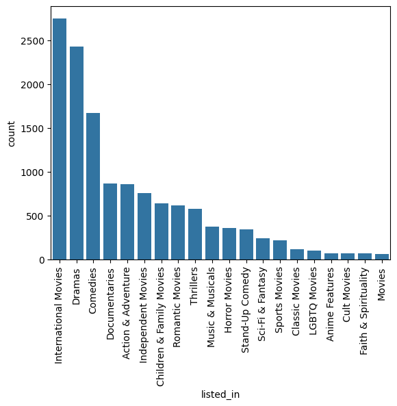

```python
sns.countplot(data= df_1,x ='listed_in',order=df_1['listed_in'].value_counts().index)
plt.xticks(rotation=90)
plt.show()
```

Insights

- Majority of movies are of international movies and dramas
- Comedies are also having higher contribution in movies dataframe.

# df_Movies(Modified)

```python
df_movies
```

|  | show_id | type | title | director | cast | country | date_added | release_year | rating | duration | listed_in | description | duration_time | date_added_datetime |
| --- | --- | --- | --- | --- | --- | --- | --- | --- | --- | --- | --- | --- | --- | --- |
| 0 | s1 | Movie | Dick Johnson Is Dead | Kirsten Johnson | NaN | United States | September 25, 2021 | 2020 | PG-13 | 90 min | Documentaries | As her father nears the end of his life, filmm... | 90.0 | 2021-09-25 |
| 6 | s7 | Movie | My Little Pony: A New Generation | Robert Cullen, José Luis Ucha | Vanessa Hudgens, Kimiko Glenn, James Marsden, ... | NaN | September 24, 2021 | 2021 | PG | 91 min | Children & Family Movies | Equestria's divided. But a bright-eyed hero be... | 91.0 | 2021-09-24 |
| 7 | s8 | Movie | Sankofa | Haile Gerima | Kofi Ghanaba, Oyafunmike Ogunlano, Alexandra D... | United States, Ghana, Burkina Faso, United Kin... | September 24, 2021 | 1993 | TV-MA | 125 min | Dramas, Independent Movies, International Movies | On a photo shoot in Ghana, an American model s... | 125.0 | 2021-09-24 |
| 9 | s10 | Movie | The Starling | Theodore Melfi | Melissa McCarthy, Chris O'Dowd, Kevin Kline, T... | United States | September 24, 2021 | 2021 | PG-13 | 104 min | Comedies, Dramas | A woman adjusting to life after a loss contend... | 104.0 | 2021-09-24 |
| 12 | s13 | Movie | Je Suis Karl | Christian Schwochow | Luna Wedler, Jannis Niewöhner, Milan Peschel, ... | Germany, Czech Republic | September 23, 2021 | 2021 | TV-MA | 127 min | Dramas, International Movies | After most of her family is murdered in a terr... | 127.0 | 2021-09-23 |
| ... | ... | ... | ... | ... | ... | ... | ... | ... | ... | ... | ... | ... | ... | ... |
| 8801 | s8802 | Movie | Zinzana | Majid Al Ansari | Ali Suliman, Saleh Bakri, Yasa, Ali Al-Jabri, ... | United Arab Emirates, Jordan | March 9, 2016 | 2015 | TV-MA | 96 min | Dramas, International Movies, Thrillers | Recovering alcoholic Talal wakes up inside a s... | 96.0 | 2016-03-09 |
| 8802 | s8803 | Movie | Zodiac | David Fincher | Mark Ruffalo, Jake Gyllenhaal, Robert Downey J... | United States | November 20, 2019 | 2007 | R | 158 min | Cult Movies, Dramas, Thrillers | A political cartoonist, a crime reporter and a... | 158.0 | 2019-11-20 |
| 8804 | s8805 | Movie | Zombieland | Ruben Fleischer | Jesse Eisenberg, Woody Harrelson, Emma Stone, ... | United States | November 1, 2019 | 2009 | R | 88 min | Comedies, Horror Movies | Looking to survive in a world taken over by zo... | 88.0 | 2019-11-01 |
| 8805 | s8806 | Movie | Zoom | Peter Hewitt | Tim Allen, Courteney Cox, Chevy Chase, Kate Ma... | United States | January 11, 2020 | 2006 | PG | 88 min | Children & Family Movies, Comedies | Dragged from civilian life, a former superhero... | 88.0 | 2020-01-11 |
| 8806 | s8807 | Movie | Zubaan | Mozez Singh | Vicky Kaushal, Sarah-Jane Dias, Raaghav Chanan... | India | March 2, 2019 | 2015 | TV-14 | 111 min | Dramas, International Movies, Music & Musicals | A scrappy but poor boy worms his way into a ty... | 111.0 | 2019-03-02 |

6131 rows × 14 columns

Q-1i) Show the genre contribution in TV dataframe?

```python
df_2 = df_TV.copy()
df_2['listed_in'] = df_2['listed_in'].apply(lambda x:x.split(','))
df_2 = df_2.explode('listed_in')
df_2['listed_in'] = df_2['listed_in'].str.strip()
df_2['listed_in'].value_counts().head(5)
```

| listed_in | count |
| --- | --- |
| International TV Shows | 1351 |
| TV Dramas | 763 |
| TV Comedies | 581 |
| Crime TV Shows | 470 |
| Kids' TV | 451 |

**dtype:** int64

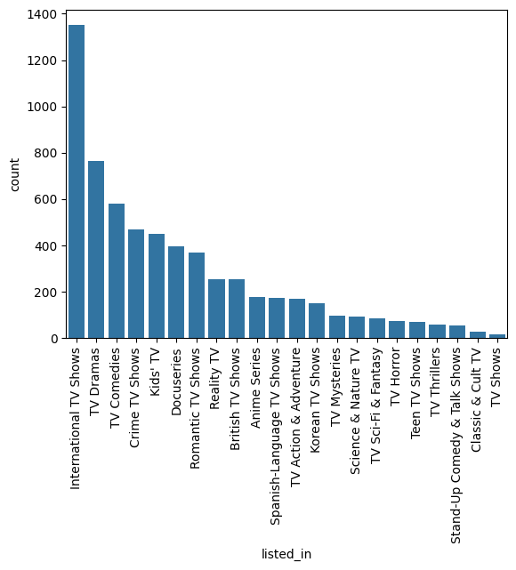

```python
sns.countplot(data= df_2,x ='listed_in',order=df_2['listed_in'].value_counts().index)
plt.xticks(rotation=90)
plt.show()
```

Insights

- Majority of TVs show are international.
- Dramas are also having higher contribution in TV shows.

Modifying dataframe of TV shows for better analysis and insights.

- Adding two columns 'Number of season and date_added(as datetime format) for better visualisation and analysis.

```python
df_TV['Number of season'] = df_TV['duration'].apply(lambda x:x[0:2])
```

```python
df_TV['date_added']=df_TV['date_added'].str.strip()
```

```python
df_TV['date_added_datetime']= pd.to_datetime(df_TV['date_added'])
```

# df_TV(Modified)

```python
df_TV
```

|  | show_id | type | title | director | cast | country | date_added | release_year | rating | duration | listed_in | description | Number of season | date_added_datetime |
| --- | --- | --- | --- | --- | --- | --- | --- | --- | --- | --- | --- | --- | --- | --- |
| 1 | s2 | TV Show | Blood & Water | NaN | Ama Qamata, Khosi Ngema, Gail Mabalane, Thaban... | South Africa | September 24, 2021 | 2021 | TV-MA | 2 Seasons | International TV Shows, TV Dramas, TV Mysteries | After crossing paths at a party, a Cape Town t... | 2 | 2021-09-24 |
| 2 | s3 | TV Show | Ganglands | Julien Leclercq | Sami Bouajila, Tracy Gotoas, Samuel Jouy, Nabi... | NaN | September 24, 2021 | 2021 | TV-MA | 1 Season | Crime TV Shows, International TV Shows, TV Act... | To protect his family from a powerful drug lor... | 1 | 2021-09-24 |
| 3 | s4 | TV Show | Jailbirds New Orleans | NaN | NaN | NaN | September 24, 2021 | 2021 | TV-MA | 1 Season | Docuseries, Reality TV | Feuds, flirtations and toilet talk go down amo... | 1 | 2021-09-24 |
| 4 | s5 | TV Show | Kota Factory | NaN | Mayur More, Jitendra Kumar, Ranjan Raj, Alam K... | India | September 24, 2021 | 2021 | TV-MA | 2 Seasons | International TV Shows, Romantic TV Shows, TV ... | In a city of coaching centers known to train I... | 2 | 2021-09-24 |
| 5 | s6 | TV Show | Midnight Mass | Mike Flanagan | Kate Siegel, Zach Gilford, Hamish Linklater, H... | NaN | September 24, 2021 | 2021 | TV-MA | 1 Season | TV Dramas, TV Horror, TV Mysteries | The arrival of a charismatic young priest brin... | 1 | 2021-09-24 |
| ... | ... | ... | ... | ... | ... | ... | ... | ... | ... | ... | ... | ... | ... | ... |
| 8795 | s8796 | TV Show | Yu-Gi-Oh! Arc-V | NaN | Mike Liscio, Emily Bauer, Billy Bob Thompson, ... | Japan, Canada | May 1, 2018 | 2015 | TV-Y7 | 2 Seasons | Anime Series, Kids' TV | Now that he's discovered the Pendulum Summonin... | 2 | 2018-05-01 |
| 8796 | s8797 | TV Show | Yunus Emre | NaN | Gökhan Atalay, Payidar Tüfekçioglu, Baran Akbu... | Turkey | January 17, 2017 | 2016 | TV-PG | 2 Seasons | International TV Shows, TV Dramas | During the Mongol invasions, Yunus Emre leaves... | 2 | 2017-01-17 |
| 8797 | s8798 | TV Show | Zak Storm | NaN | Michael Johnston, Jessica Gee-George, Christin... | United States, France, South Korea, Indonesia | September 13, 2018 | 2016 | TV-Y7 | 3 Seasons | Kids' TV | Teen surfer Zak Storm is mysteriously transpor... | 3 | 2018-09-13 |
| 8800 | s8801 | TV Show | Zindagi Gulzar Hai | NaN | Sanam Saeed, Fawad Khan, Ayesha Omer, Mehreen ... | Pakistan | December 15, 2016 | 2012 | TV-PG | 1 Season | International TV Shows, Romantic TV Shows, TV ... | Strong-willed, middle-class Kashaf and carefre... | 1 | 2016-12-15 |
| 8803 | s8804 | TV Show | Zombie Dumb | NaN | NaN | NaN | July 1, 2019 | 2018 | TV-Y7 | 2 Seasons | Kids' TV, Korean TV Shows, TV Comedies | While living alone in a spooky town, a young g... | 2 | 2019-07-01 |

2676 rows × 14 columns

```python
df_TV.info()
```

```
<class 'pandas.core.frame.DataFrame'>
Index: 2676 entries, 1 to 8803
Data columns (total 14 columns):
 #   Column               Non-Null Count  Dtype
---  ------               --------------  -----
 0   show_id              2676 non-null   object
 1   type                 2676 non-null   object
 2   title                2676 non-null   object
 3   director             230 non-null    object
 4   cast                 2326 non-null   object
 5   country              2285 non-null   object
 6   date_added           2666 non-null   object
 7   release_year         2676 non-null   int64
 8   rating               2674 non-null   object
 9   duration             2676 non-null   object
 10  listed_in            2676 non-null   object
 11  description          2676 non-null   object
 12  Number of season     2676 non-null   object
 13  date_added_datetime  2666 non-null   datetime64[ns]
dtypes: datetime64[ns](1), int64(1), object(12)
memory usage: 378.1+ KB
```

Q-1j) How has the number of movies & TV released per year changed over the last 20-30 years?

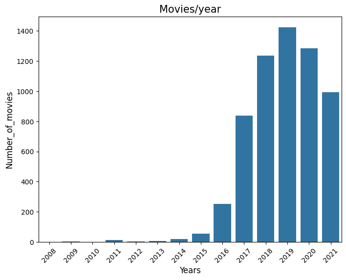

```python
#movies
plt.figure(figsize=(8,6))
plt.xlabel("Years",fontsize =12)
plt.ylabel("Number_of_movies",fontsize =12)
sns.countplot(data=df_movies,x=df_movies['date_added_datetime'].dt.year)
plt.xticks(rotation=45)
plt.title("Movies/year",fontsize =15)
```

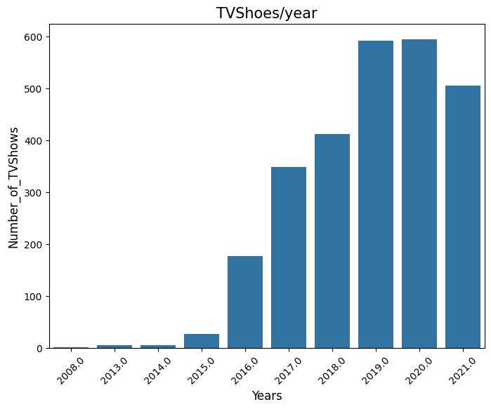

```python
#TVshows
plt.figure(figsize=(8,6))
plt.xlabel("Years",fontsize =12)
plt.ylabel("Number_of_TVShows",fontsize =12)
sns.countplot(data=df_TV,x=df_TV['date_added_datetime'].dt.year)
plt.xticks(rotation=45)
plt.title("TVShoes/year",fontsize =15)
```

Insights

NOTE: Data for the year 2021 should not be considered because data is till mid 2021 only.

Q-1k) Does Netflix has more focus on TV Shows than movies in recent years

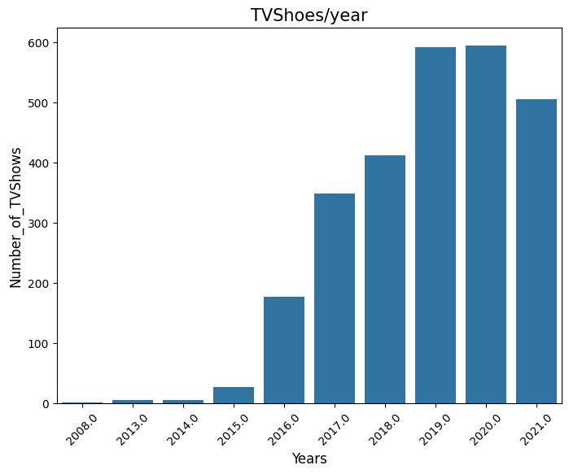

```python
plt.figure(figsize=(8,6))
plt.xlabel("Years",fontsize =12)
plt.ylabel("Number_of_TVShows",fontsize =12)
sns.countplot(data=df_TV,x=df_TV['date_added_datetime'].dt.year)
plt.xticks(rotation=45)
plt.title("TVShoes/year",fontsize =15)
```

Insights

NOTE: Data for the year 2021 should not be considered because data is till mid 2021 only.

Q-1l) What is the best time to launch a TV show and Movies ?

```python
df_TV['date_added_datetime'].dt.month.value_counts().head(5)
```

| date_added_datetime | count |
| --- | --- |
| 12.0 | 266 |
| 7.0 | 262 |
| 9.0 | 251 |
| 8.0 | 236 |
| 6.0 | 236 |

**dtype:** int64

```python
df_movies['date_added_datetime'].dt.month.value_counts().head(5)
```

| date_added_datetime | count |
| --- | --- |
| 7 | 565 |
| 4 | 550 |
| 12 | 547 |
| 1 | 546 |
| 10 | 545 |

**dtype:** int64

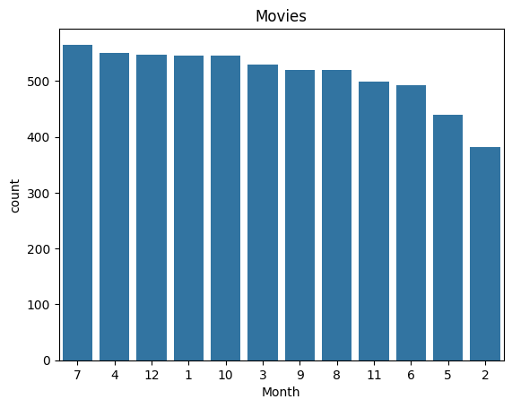

```python
sns.countplot(data =df_movies,x=df_movies['date_added_datetime'].dt.month,order =df_movies['date_added_datetime'].dt.month.value_counts().index)
plt.xlabel('Month')
plt.title('Movies')
```

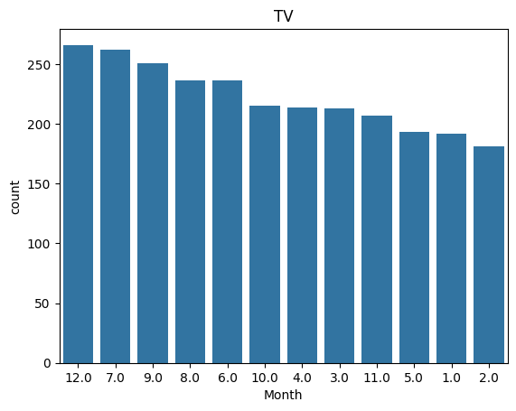

```python
sns.countplot(data =df_TV,x=df_TV['date_added_datetime'].dt.month,order =df_TV['date_added_datetime'].dt.month.value_counts().index)
plt.xlabel('Month')
plt.title('TV')
```

Insights

- Launching of TV shows should be in the december month as most tv shows are released in that month and also because of holidays and new year more people will watch.

Q-1m) Understanding how much movie duration consumed in different countries ?

```python
df_3 = df_movies_explode.copy()
df_3 = df_3.reset_index(drop=True)
df_3['duration_time'] = df_3['duration'].dropna().apply(lambda x:x[0:-4]).astype('int')
```

```python
df_3.groupby('country')['duration_time'].describe().sort_values('count',ascending = False).head(10)
```

| country | count | mean | std | min | 25% | 50% | 75% | max |
| --- | --- | --- | --- | --- | --- | --- | --- | --- |
| United States | 2749.0 | 93.753729 | 25.200855 | 3.0 | 84.0 | 94.0 | 106.00 | 312.0 |
| India | 962.0 | 125.912682 | 25.795535 | 29.0 | 110.0 | 126.5 | 142.00 | 228.0 |
| United Kingdom | 534.0 | 98.760300 | 26.288603 | 15.0 | 89.0 | 98.0 | 112.00 | 224.0 |
| Canada | 319.0 | 91.150470 | 22.350747 | 19.0 | 85.5 | 92.0 | 103.00 | 158.0 |
| France | 303.0 | 100.973597 | 19.004164 | 22.0 | 91.0 | 99.0 | 111.00 | 186.0 |
| Germany | 182.0 | 103.005495 | 22.355613 | 21.0 | 91.0 | 101.0 | 116.75 | 186.0 |
| Spain | 171.0 | 101.099415 | 18.446953 | 25.0 | 91.0 | 100.0 | 110.00 | 180.0 |
| Japan | 119.0 | 98.848739 | 28.069719 | 5.0 | 88.5 | 99.0 | 112.00 | 208.0 |
| China | 114.0 | 104.456140 | 15.526820 | 44.0 | 94.0 | 105.0 | 112.50 | 141.0 |
| Mexico | 111.0 | 90.603604 | 26.298385 | 25.0 | 78.5 | 93.0 | 105.00 | 152.0 |

```python
df_3['country'].value_counts().index[:3]
```

```
Index(['United States', 'India', 'United Kingdom'], dtype='object', name='country')
```

Insights

- USA has mean duration time of movies approx 1 hr and 30mins, whereas in India it is approx 2 hrs.
- Uk also has average duration time of 90mins.
- 75 percentile of movies in india have duration time of less than 142 mins whereas for USA and UK it is 106-112 mins.
- Some outliers for USA is having movie time of 312mins and whereas for India it is 228min.

Q-1n) Understanding how much TV seasons consumed in different countries ?

```python
df_4 = df_TV_explode.copy()
df_4 = df_4.reset_index(drop=True)
df_4['Number of season'] = df_4['duration'].apply(lambda x:x[0:1]).astype('int')
#df_4['Number of season']
```

```python
df_4.groupby('country')['Number of season'].describe().sort_values('count',ascending = False).head(5)
```

| country | count | mean | std | min | 25% | 50% | 75% | max |
| --- | --- | --- | --- | --- | --- | --- | --- | --- |
| United States | 847.0 | 2.180638 | 1.757578 | 1.0 | 1.0 | 1.0 | 3.0 | 9.0 |
| United Kingdom | 246.0 | 1.808943 | 1.425741 | 1.0 | 1.0 | 1.0 | 2.0 | 9.0 |
| Japan | 174.0 | 1.568966 | 1.124279 | 1.0 | 1.0 | 1.0 | 2.0 | 9.0 |
| South Korea | 164.0 | 1.201220 | 0.588018 | 1.0 | 1.0 | 1.0 | 1.0 | 6.0 |
| United States | 91.0 | 1.967033 | 1.394039 | 1.0 | 1.0 | 1.0 | 2.0 | 7.0 |

Insights

Q-1o) Find After how many days the movie will be added to Netflix after the release of the movie?

```python
(df_movies['date_added_datetime'].dt.year - df_movies['release_year']).value_counts().head(10)
```

|  | count |
| --- | --- |
| 0 | 1862 |
| 1 | 1178 |
| 2 | 491 |
| 3 | 347 |
| 4 | 273 |
| 5 | 191 |
| 6 | 181 |
| 8 | 147 |
| 7 | 139 |
| 9 | 128 |

**dtype:** int64

```python
(df_TV['date_added_datetime'].dt.year - df_TV['release_year']).value_counts().head(10)
```

|  | count |
| --- | --- |
| 0.0 | 1379 |
| 1.0 | 407 |
| 2.0 | 223 |
| 3.0 | 144 |
| 4.0 | 94 |
| 5.0 | 70 |
| 6.0 | 70 |
| 7.0 | 48 |
| 8.0 | 38 |
| 9.0 | 33 |

**dtype:** int64

Insights

- 1st Non visual plot gives for movies and we can say most of the movies released on netflix were in the same year as it was released in cinemas also i.e 1862 number of releases.
- 2nd Non visual plot gives for TV shows and we can say most of the TV shows released on netflix were in the same year as it was released in cinemas also i.e 1379 number of releases.

Q-1p). Analysis of actors/directors of different types of shows/movies.

```python
df_movies['cast'].dropna().apply(lambda x:x.split(',')).explode().value_counts().head(10)
```

| cast | count |
| --- | --- |
| Anupam Kher | 38 |
| Rupa Bhimani | 27 |
| Om Puri | 27 |
| Shah Rukh Khan | 26 |
| Boman Irani | 25 |
| Paresh Rawal | 25 |
| Julie Tejwani | 24 |
| Akshay Kumar | 23 |
| Rajesh Kava | 21 |
| Kareena Kapoor | 20 |

**dtype:** int64

```python
df_TV['cast'].dropna().apply(lambda x:x.split(',')).explode().value_counts().head(10)
```

| cast | count |
| --- | --- |
| Takahiro Sakurai | 24 |
| Yuki Kaji | 17 |
| Junichi Suwabe | 17 |
| Ai Kayano | 17 |
| Daisuke Ono | 14 |
| David Attenborough | 14 |
| Takehito Koyasu | 13 |
| Yoshimasa Hosoya | 13 |
| Yuichi Nakamura | 13 |
| Tomokazu Sugita | 12 |

**dtype:** int64

Insights Top 10 most frequently appearing cast members.

- 1st Non visual plot gives for movies and actor who has most movies on netflix is anupam kher.
- 2nd Non visual plot gives for TV shows and actor who has most Tv shows on netflix is Takahiro Sakurai.

```python
df_movies['director'].dropna().apply(lambda x:x.split(',')).explode().value_counts().head(10)
```

| director | count |
| --- | --- |
| Rajiv Chilaka | 22 |
| Jan Suter | 18 |
| Raúl Campos | 18 |
| Suhas Kadav | 16 |
| Jay Karas | 15 |
| Marcus Raboy | 15 |
| Cathy Garcia-Molina | 13 |
| Jay Chapman | 12 |
| Youssef Chahine | 12 |
| Martin Scorsese | 12 |

**dtype:** int64

```python
df_TV['director'].dropna().apply(lambda x:x.split(',')).explode().value_counts().head(10)
```

| director | count |
| --- | --- |
| Alastair Fothergill | 3 |
| Ken Burns | 3 |
| Jung-ah Im | 2 |
| Joe Berlinger | 2 |
| Shin Won-ho | 2 |
| Gautham Vasudev Menon | 2 |
| Hsu Fu-chun | 2 |
| Stan Lathan | 2 |
| Iginio Straffi | 2 |
| Rob Seidenglanz | 2 |

**dtype:** int64

Insights Top 10 most frequently director releases on netflix.

- 1st Non visual plot is of movies gives for director who has most movies on netflix is Rajiv Chilaka.
- 2nd Non visual plot is of TV shows and director who has most tv shows are Alastair Fothergill,Ken Burns i.e 3 , most director has atleast 2 tv shows on netflix.

# Q-3) Non-Graphical Analysis: Value counts and unique attributes

Q 3a)- Show the value_counts of rating, country,genre(listed_in),Number of season,duration time?

```python
df_movies_explode['country'].value_counts().head(10)
```

| country | count |
| --- | --- |
| United States | 2752 |
| India | 962 |
| United Kingdom | 534 |
| Canada | 319 |
| France | 303 |
| Germany | 182 |
| Spain | 171 |
| Japan | 119 |
| China | 114 |
| Mexico | 111 |

**dtype:** int64

```python
df_TV_explode['country'].value_counts().head(10)
```

| country | count |
| --- | --- |
| United States | 847 |
| United Kingdom | 246 |
| Japan | 174 |
| South Korea | 164 |
| United States | 91 |
| Canada | 84 |
| India | 81 |
| Taiwan | 70 |
| France | 64 |
| Australia | 56 |

**dtype:** int64

Insights -

1. Above non graphical tables are of no. of movies/TV released in different countries.
2. USA holds the majority of market

```python
df_movies['rating'].value_counts().head(10)
```

| rating | count |
| --- | --- |
| TV-MA | 2062 |
| TV-14 | 1427 |
| R | 797 |
| TV-PG | 540 |
| PG-13 | 490 |
| PG | 287 |
| TV-Y7 | 139 |
| TV-Y | 131 |
| TV-G | 126 |
| NR | 75 |

**dtype:** int64

```python
df_TV['rating'].value_counts().head(10)
```

| rating | count |
| --- | --- |
| TV-MA | 1145 |
| TV-14 | 733 |
| TV-PG | 323 |
| TV-Y7 | 195 |
| TV-Y | 176 |
| TV-G | 94 |
| NR | 5 |
| R | 2 |
| TV-Y7-FV | 1 |

**dtype:** int64

Insights -

1. Above non graphical tables are of rating criteria.
2. Movies/Shows released as TV-MA rating are major. TV-MA stands for mature audience

```python
df_1['listed_in'].value_counts().head(5)
# Movies
```

| listed_in | count |
| --- | --- |
| International Movies | 2752 |
| Dramas | 2427 |
| Comedies | 1674 |
| Documentaries | 869 |
| Action & Adventure | 859 |

**dtype:** int64

```python
df_2['listed_in'].value_counts().head(5)
#tv Shows
```

| listed_in | count |
| --- | --- |
| International TV Shows | 1351 |
| TV Dramas | 763 |
| TV Comedies | 581 |
| Crime TV Shows | 470 |
| Kids' TV | 451 |

**dtype:** int64

Insights -

1. Above non graphical tables are of Genre(listed_in column).
2. Movies released as an'International and dramas' genre are much higher than rest of the others.
3. TV Shows released as an'International TV shows' genre are much higher than rest of the others.

```python
df_TV['Number of season'].value_counts()
#TVShows
```

| Number of season | count |
| --- | --- |
| 1 | 1793 |
| 2 | 425 |
| 3 | 199 |
| 4 | 95 |
| 5 | 65 |
| 6 | 33 |
| 7 | 23 |
| 8 | 17 |
| 9 | 9 |
| 10 | 7 |
| 13 | 3 |
| 15 | 2 |
| 12 | 2 |
| 11 | 2 |
| 17 | 1 |

**dtype:** int64

```python
df_movies['duration_time'].value_counts()
#Movies
```

| duration_time | count |
| --- | --- |
| 90.0 | 152 |
| 94.0 | 146 |
| 93.0 | 146 |
| 97.0 | 146 |
| 91.0 | 144 |
| ... | ... |
| 212.0 | 1 |
| 8.0 | 1 |
| 186.0 | 1 |
| 193.0 | 1 |
| 191.0 | 1 |

205 rows × 1 columns

**dtype:** int64

Insights -

1. Most number of TV shows released on Netflix released has 1 season.
2. Mostly Movies released on netflix are of duration 90- 100 minutes.
3. Some outliers are also having season for more than 9 for TV shows.
4. Lesser shows were released having season of 4 or more.
5. Some outliers in movies are having duration of approv 200min also.

# Q-5. Missing Value & Outlier check (Treatment optional) (10 Points)

```python
df_movies.isna().sum()
```

|  | 0 |
| --- | --- |
| show_id | 0 |
| type | 0 |
| title | 0 |
| director | 188 |
| cast | 475 |
| country | 440 |
| date_added | 0 |
| release_year | 0 |
| rating | 2 |
| duration | 3 |
| listed_in | 0 |
| description | 0 |
| duration_time | 3 |
| date_added_datetime | 0 |

**dtype:** int64

```python
df_TV.isna().sum()
```

|  | 0 |
| --- | --- |
| show_id | 0 |
| type | 0 |
| title | 0 |
| director | 2446 |
| cast | 350 |
| country | 391 |
| date_added | 10 |
| release_year | 0 |
| rating | 2 |
| duration | 0 |
| listed_in | 0 |
| description | 0 |
| Number of season | 0 |
| date_added_datetime | 10 |

**dtype:** int64

Insights -

- These are number of rows missing in those columns.
- For movies missing values are in the column 'cast','country','director'.
- For TV shows missing values in the column 'director', 'cast','country'.

```python
# we can fill this missing values of categorical data with NA(not available) or 0(for continous data)
df_movies['cast'].fillna('NA').isna().sum()
```

```
0
```

```python
df_movies['country'].fillna('NA').isna().sum()
```

```
0
```

```python
df_movies['director'].fillna('NA').isna().sum()
```

```
0
```

```python
df_movies['rating'].fillna('NA').isna().sum()
```

```
0
```

```python
df_movies['duration'].fillna(0).isna().sum()
```

```
0
```

```python
df_TV['cast'].fillna('NA').isna().sum()
```

```
0
```

```python
df_TV['country'].fillna('NA').isna().sum()
```

```
0
```

```python
df_TV['director'].fillna('NA').isna().sum()
```

```
0
```

```python
df_TV['rating'].fillna('NA').isna().sum()
```

```
0
```

```python
df_TV['date_added'].fillna('NA').isna().sum()
```

```
0
```

Treatment:

# Q-4 Visual Analysis - Univariate, Bivariate after pre-processing of the data

Note: Pre-processing involves unnesting of the data in columns like Actor, Director, Country

Q 4a)- For continuous variable(s): Distplot, countplot, histogram for univariate analysis?

```python
top4_country = df_4['country'].value_counts().index[:4]
top4_country
#tv shows data
```

```
Index(['United States', 'United Kingdom', 'Japan', 'South Korea'], dtype='object', name='country')
```

```python
top4_country_df = df_4.loc[df_4['country'].isin(top4_country)]
#tv shows data
```

```python
top5_country= df_3['country'].value_counts().index[:5]
#movie data
```

```python
top5_country_df = df_3.loc[df_3['country'].isin(top5_country)]
#movie data
```

Q 4b)- countplot for univariate analysis?

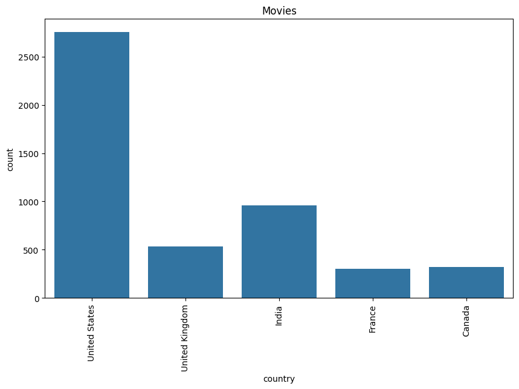

```python
plt.figure(figsize=(10,6))
sns.countplot(data=top5_country_df,x='country')
plt.xticks(rotation = 90)
plt.title("Movies")
plt.show()
```

Insights:

- This is countplot for univariate analysis (categories as country) for Movies.
- This are top 5 countries by number of movie releases.
- USA releases most movies and then India in second.

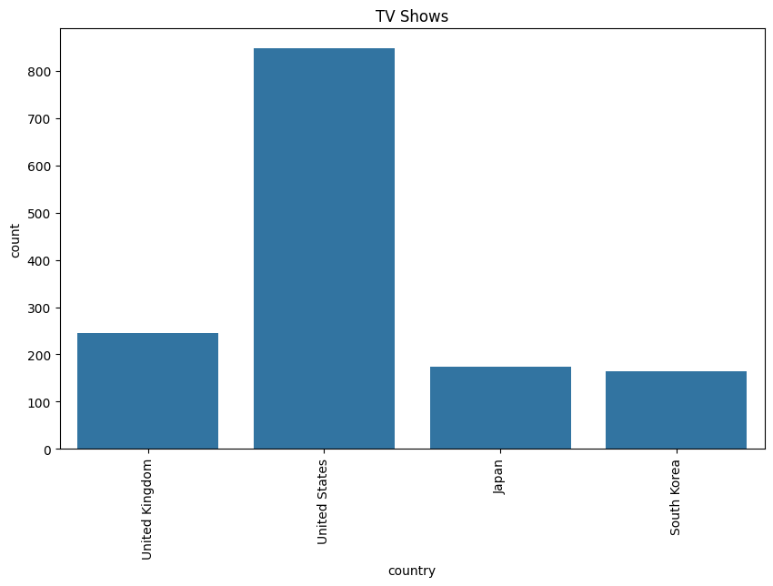

```python
plt.figure(figsize=(10,6))
sns.countplot(data=top4_country_df,x='country')
plt.xticks(rotation = 90)
plt.title("TV Shows")
plt.show()
```

Insights:

- This are top 4 countries by number of TV show releases.
- This is countplot for univariate analysis (categories as country) for TV shows.
- USA releases most TV shows.

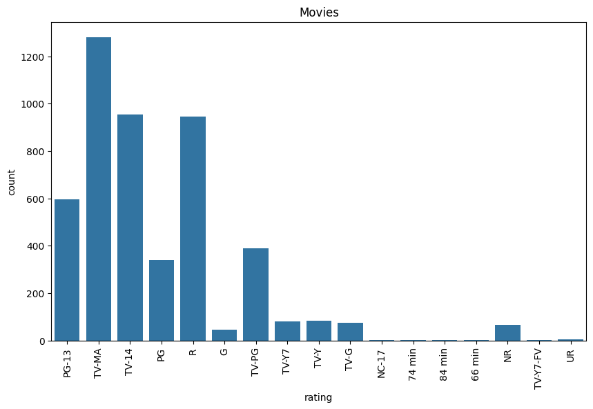

```python
plt.figure(figsize=(10,6))
sns.countplot(data=top5_country_df,x='rating')
plt.xticks(rotation = 90)
plt.title("Movies")
plt.show()
```

Insights:

Analysis is done on top 5 countries(number of movie releases).

- This is countplot for univariate analysis (categories as rating) for movies.
- Movie released under rating TV -MA(mature audience) are much higher

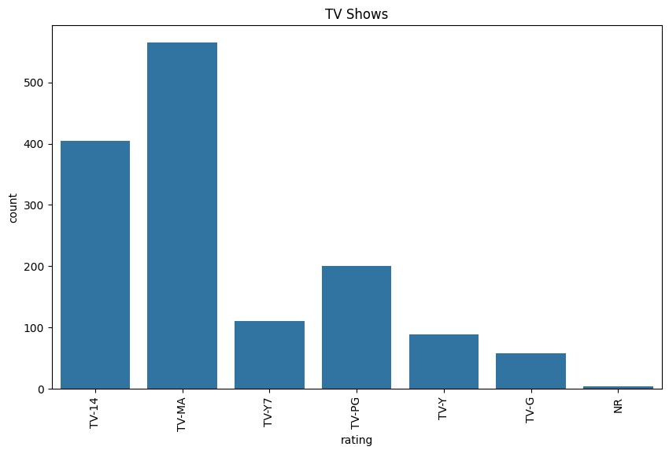

```python
plt.figure(figsize=(10,6))
sns.countplot(data=top4_country_df,x='rating')
plt.xticks(rotation = 90)
plt.title("TV Shows")
plt.show()
```

Insights:

Analysis is done on top 4 countries(number of TV shows releases).

- This is countplot for univariate analysis (categories as rating) for TV Shows.
- TV shows released under rating TV -MA(mature audience) are much higher.

Q 4c)- histogram for univariate analysis?

```python
dummy_movie = pd.DataFrame(df_movies['date_added_datetime'].dt.year)
```

```python
dummy_tv = pd.DataFrame(df_TV['date_added_datetime'].dt.year)
```

```python
dummy_tv['date_added_datetime'].min(),dummy_tv['date_added_datetime'].max()
```

```
(2008.0, 2021.0)
```

```python
dummy_movie['date_added_datetime'].min(),dummy_movie['date_added_datetime'].max()
```

```
(2008, 2021)
```

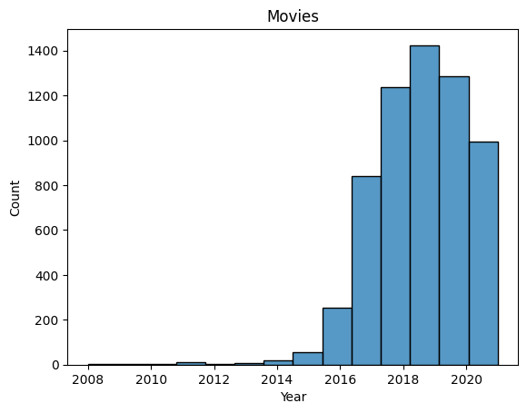

```python
sns.histplot(dummy_movie['date_added_datetime'],bins =14)
plt.xlabel("Year")
plt.title("Movies")
plt.show()
```

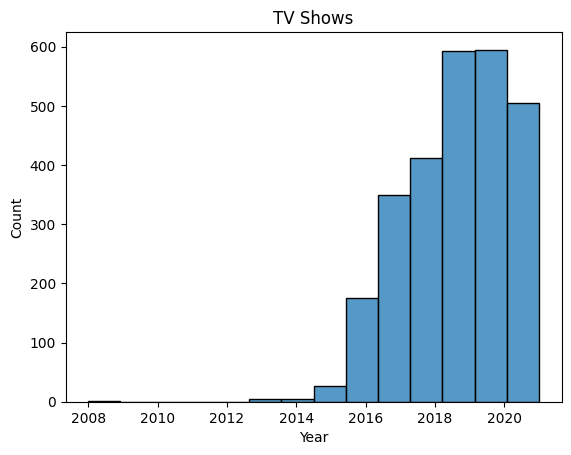

```python
sns.histplot(dummy_tv['date_added_datetime'],bins =14)
plt.title("TV Shows")
plt.xlabel('Year')
plt.show()
```

Insights:

This is histogram graph ,it is a frequency vs range graph.

- Frequency in releasing movie from the last couple of years are dropping as we can see in the histogram plot.
- Frequency in releasing TV shows from the last couple of years are rising as we can see in the histogram plot.

NOTE: Data for the year 2021 should not be considered because data is till mid 2021 only.

Q 4d-) For categorical variable(s): Dodged countplot

Releases of movies/tvshows for countries wrt to year ?

```python
dum_mo = df_movies.loc[df_movies['country'].isin(top5_country)]
```

```python
dum_tv = df_TV.loc[df_TV['country'].isin(top4_country)]
```

```python
dum_tv['year'] = dum_tv['date_added_datetime'].dt.year
```

```python
dum_mo['year'] = dum_mo['date_added_datetime'].dt.year
```

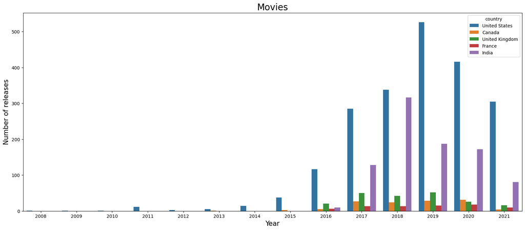

```python
plt.figure(figsize=(20,8))
sns.countplot(x='year',hue='country',data=dum_mo)
plt.title('Movies',fontsize=20)
plt.ylabel('Number of releases',fontsize=15)
plt.xlabel('Year',fontsize=15)
plt.show()
```

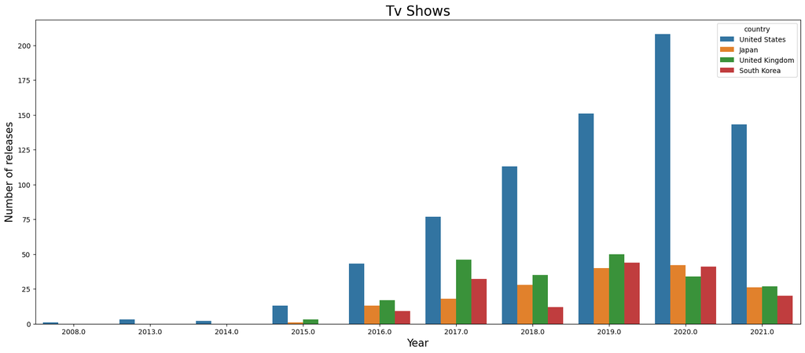

```python
plt.figure(figsize=(20,8))
sns.countplot(x='year',hue='country',data=dum_tv)
plt.title('Tv Shows',fontsize=20)
plt.ylabel('Number of releases',fontsize=15)
plt.xlabel('Year',fontsize=15)
plt.show()
```

NOTE: Data for the year 2021 should not be considered because data is till mid 2021 only.

Q 4e-) For categorical variable(s): Dodged countplot

Releases of ratings of movies/TVshow wrt to year

```python
dum_mo_rating = dum_mo.loc[dum_mo['rating'].isin(dum_mo['rating'].value_counts().index[:4])]
```

```python
dum_mo_rating2 = dum_mo_rating.loc[(dum_mo_rating['year'] == 2017)|(dum_mo_rating['year'] == 2018)| (dum_mo_rating['year'] == 2019) | (dum_mo_rating['year'] == 2020)]
```

```python
dum_tv_rating = dum_tv.loc[dum_tv['rating'].isin(dum_tv['rating'].value_counts().index[:4])]
```

```python
dum_tv_rating2 = dum_tv_rating.loc[(dum_tv_rating['year'] == 2017)|(dum_tv_rating['year'] == 2018)| (dum_tv_rating['year'] == 2019) | (dum_tv_rating['year'] == 2020)]
```

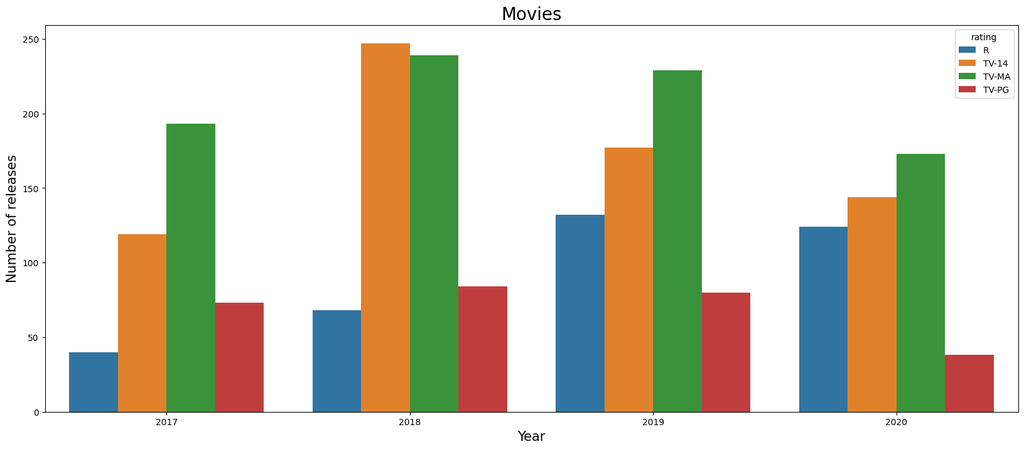

```python
plt.figure(figsize=(20,8))
sns.countplot(x='year',hue='rating',data=dum_mo_rating2)
plt.title('Movies',fontsize=20)
plt.ylabel('Number of releases',fontsize=15)
plt.xlabel('Year',fontsize=15)
plt.show()
```

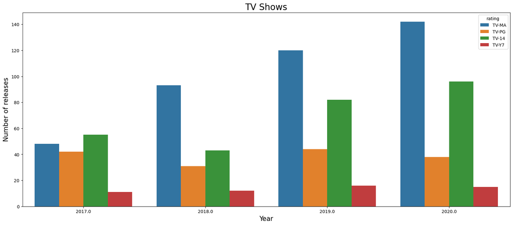

```python
plt.figure(figsize=(20,8))
sns.countplot(x='year',hue='rating',data=dum_tv_rating2)
plt.title('TV Shows',fontsize=20)
plt.ylabel('Number of releases',fontsize=15)
plt.xlabel('Year',fontsize=15)
plt.show()
```

Insights: This analysis is done focusing top 5 country(based on number of release on netflix). In this we are focusing after 2017 year only.

TV MA :- Mature audience R :- Restriced TV PG :- Parental Guidance

NOTE: Data for the year 2021 should not be considered because data is till mid 2021 only.

Q 4f-) For categorical variable(s): Box plot

Movie duration/TV Seasons consumed in top 3 countries(in terms of releases)

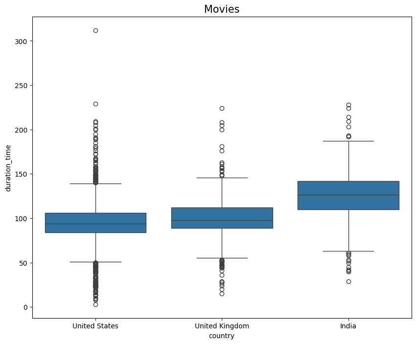

```python
plt.figure(figsize=(10,8))
plt.title('Movies',fontsize =15)
sns.boxplot(x='country', y='duration_time',data=df_3.loc[(df_3['country']=='United States')|(df_3['country']=='India')|(df_3['country']=='United Kingdom')])
```

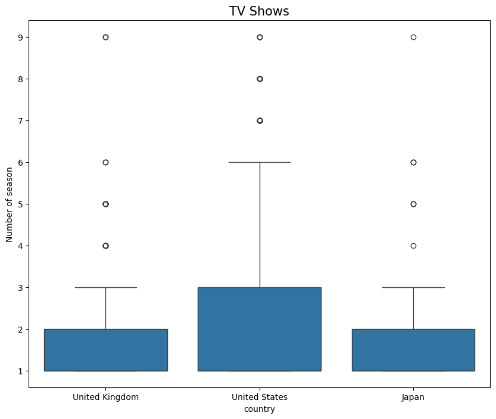

```python
plt.figure(figsize=(10,8))
plt.title('TV Shows',fontsize =15)
sns.boxplot(x='country', y='Number of season',data=df_4.loc[(df_4['country']=='United States')|(df_4['country']=='United Kingdom')|(df_4['country']=='Japan')])
```

Insights: This analysis is done focusing top 3 country(based on number of release on netflix).

- Movies:- Mean duration time of USA and UK is almost same i.e 90-100minutes.
- In india mean duration time is approx 120 minutes.
- 75 percentile for USA UK are under 120minutes only,where as for India 75 percentile movies are under 140minutes.
- Tv Shows :- 75% percentile Tv shows of USA has 3 seasons, whereas in UK it is 2 seasons and same for japan.

Q 4g-) For categorical variable(s): Dodged countplot

Trends in in genres of movies/TVshow wrt to year

```python
df_1['listed_in'].value_counts().index[:3]
```

```
Index(['International Movies', 'Dramas', 'Comedies'], dtype='object', name='listed_in')
```

```python
df_2['listed_in'].value_counts().index[:5]
```

```
Index(['International TV Shows', 'TV Dramas', 'TV Comedies', 'Crime TV Shows',
       'Kids' TV'],
      dtype='object', name='listed_in')
```

```python
new_df = df_1.loc[df_1['listed_in'].isin(df_1['listed_in'].value_counts().index[:5])]
new_df['year'] = new_df['date_added_datetime'].dt.year
new_df = new_df.loc[(new_df['year']==2017)|(new_df['year']==2018)|(new_df['year']==2019)|(new_df['year']==2020)]
new_df.head(5)
```

|  | show_id | type | title | director | cast | country | date_added | release_year | rating | duration | listed_in | description | duration_time | date_added_datetime | year |
| --- | --- | --- | --- | --- | --- | --- | --- | --- | --- | --- | --- | --- | --- | --- | --- |
| 1470 | s1471 | Movie | Alaska Is a Drag | Shaz Bennett | Martin L. Washington Jr., Maya Washington, Mat... | United States | December 31, 2020 | 2017 | TV-MA | 83 min | Dramas | Tormented by bullies, an aspiring drag star wo... | 83.0 | 2020-12-31 | 2020 |
| 1472 | s1473 | Movie | Bobby Jasoos | Samar Shaikh | Vidya Balan, Ali Fazal, Supriya Pathak, Tanvi ... | India | December 31, 2020 | 2014 | TV-14 | 116 min | Comedies | With unlimited determination and zero field ex... | 116.0 | 2020-12-31 | 2020 |
| 1472 | s1473 | Movie | Bobby Jasoos | Samar Shaikh | Vidya Balan, Ali Fazal, Supriya Pathak, Tanvi ... | India | December 31, 2020 | 2014 | TV-14 | 116 min | Dramas | With unlimited determination and zero field ex... | 116.0 | 2020-12-31 | 2020 |
| 1472 | s1473 | Movie | Bobby Jasoos | Samar Shaikh | Vidya Balan, Ali Fazal, Supriya Pathak, Tanvi ... | India | December 31, 2020 | 2014 | TV-14 | 116 min | International Movies | With unlimited determination and zero field ex... | 116.0 | 2020-12-31 | 2020 |
| 1474 | s1475 | Movie | Tarung Sarung | Archie Hekagery | Panji Zoni, Yayan Ruhian, Maizura, Cemal Faruk... | Indonesia | December 31, 2020 | 2020 | TV-PG | 116 min | Action & Adventure | Wealthy and spoiled, a young man finds somethi... | 116.0 | 2020-12-31 | 2020 |

```python
new_df_2 = df_2.copy()
```

```python
new_df_2['date_added'] = new_df_2['date_added'].str.strip()
```

```python
new_df_2['date_added_datetime'] = pd.to_datetime(new_df_2['date_added'])
```

```python
new_df_2['year'] = new_df_2['date_added_datetime'].dt.year
```

```python
new_df_2.head(2)
```

|  | show_id | type | title | director | cast | country | date_added | release_year | rating | duration | listed_in | description | date_added_datetime | year |
| --- | --- | --- | --- | --- | --- | --- | --- | --- | --- | --- | --- | --- | --- | --- |
| 1 | s2 | TV Show | Blood & Water | NaN | Ama Qamata, Khosi Ngema, Gail Mabalane, Thaban... | South Africa | September 24, 2021 | 2021 | TV-MA | 2 Seasons | International TV Shows | After crossing paths at a party, a Cape Town t... | 2021-09-24 | 2021.0 |
| 1 | s2 | TV Show | Blood & Water | NaN | Ama Qamata, Khosi Ngema, Gail Mabalane, Thaban... | South Africa | September 24, 2021 | 2021 | TV-MA | 2 Seasons | TV Dramas | After crossing paths at a party, a Cape Town t... | 2021-09-24 | 2021.0 |

```python
new_df_2 = new_df_2.loc[new_df_2['listed_in'].isin(new_df_2['listed_in'].value_counts().index[:5])]
new_df_2 = new_df_2.loc[(new_df_2['year']==2017)|(new_df_2['year']==2018)|(new_df_2['year']==2019)|(new_df_2['year']==2020)]
new_df_2
```

|  | show_id | type | title | director | cast | country | date_added | release_year | rating | duration | listed_in | description | date_added_datetime | year |
| --- | --- | --- | --- | --- | --- | --- | --- | --- | --- | --- | --- | --- | --- | --- |
| 1477 | s1478 | TV Show | Dare Me | NaN | Willa Fitzgerald, Herizen Guardiola, Marlo Kel... | United States | December 30, 2020 | 2019 | TV-MA | 1 Season | Crime TV Shows | Relationships topple and loyalties flip when a... | 2020-12-30 | 2020.0 |
| 1477 | s1478 | TV Show | Dare Me | NaN | Willa Fitzgerald, Herizen Guardiola, Marlo Kel... | United States | December 30, 2020 | 2019 | TV-MA | 1 Season | TV Dramas | Relationships topple and loyalties flip when a... | 2020-12-30 | 2020.0 |
| 1478 | s1479 | TV Show | Equinox | NaN | Danica Curcic, Karoline Hamm, Viola Martinsen,... | Denmark, United States | December 30, 2020 | 2020 | TV-MA | 1 Season | International TV Shows | Haunted by visions after her sister vanished w... | 2020-12-30 | 2020.0 |
| 1479 | s1480 | TV Show | SanPa: Sins of the Savior | Cosima Spender | NaN | Italy | December 30, 2020 | 2020 | TV-MA | 1 Season | Crime TV Shows | Amidst a heroin crisis, Vincenzo Muccioli care... | 2020-12-30 | 2020.0 |
| 1479 | s1480 | TV Show | SanPa: Sins of the Savior | Cosima Spender | NaN | Italy | December 30, 2020 | 2020 | TV-MA | 1 Season | International TV Shows | Amidst a heroin crisis, Vincenzo Muccioli care... | 2020-12-30 | 2020.0 |
| ... | ... | ... | ... | ... | ... | ... | ... | ... | ... | ... | ... | ... | ... | ... |
| 8796 | s8797 | TV Show | Yunus Emre | NaN | Gökhan Atalay, Payidar Tüfekçioglu, Baran Akbu... | Turkey | January 17, 2017 | 2016 | TV-PG | 2 Seasons | International TV Shows | During the Mongol invasions, Yunus Emre leaves... | 2017-01-17 | 2017.0 |
| 8796 | s8797 | TV Show | Yunus Emre | NaN | Gökhan Atalay, Payidar Tüfekçioglu, Baran Akbu... | Turkey | January 17, 2017 | 2016 | TV-PG | 2 Seasons | TV Dramas | During the Mongol invasions, Yunus Emre leaves... | 2017-01-17 | 2017.0 |
| 8797 | s8798 | TV Show | Zak Storm | NaN | Michael Johnston, Jessica Gee-George, Christin... | United States, France, South Korea, Indonesia | September 13, 2018 | 2016 | TV-Y7 | 3 Seasons | Kids' TV | Teen surfer Zak Storm is mysteriously transpor... | 2018-09-13 | 2018.0 |
| 8803 | s8804 | TV Show | Zombie Dumb | NaN | NaN | NaN | July 1, 2019 | 2018 | TV-Y7 | 2 Seasons | Kids' TV | While living alone in a spooky town, a young g... | 2019-07-01 | 2019.0 |
| 8803 | s8804 | TV Show | Zombie Dumb | NaN | NaN | NaN | July 1, 2019 | 2018 | TV-Y7 | 2 Seasons | TV Comedies | While living alone in a spooky town, a young g... | 2019-07-01 | 2019.0 |

2663 rows × 14 columns

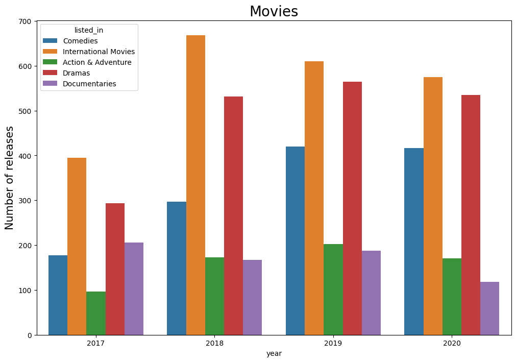

```python
plt.figure(figsize=(12,8))
plt.title('Movies',fontsize=20)
plt.ylabel('Number of releases',fontsize=15)
sns.countplot(x='year',hue='listed_in',data= new_df)
plt.show()
```

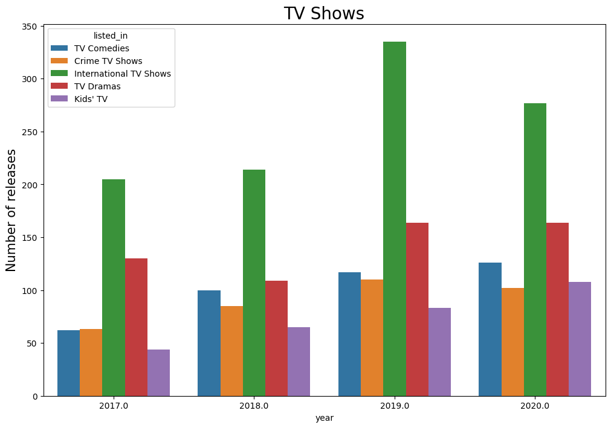

```python
plt.figure(figsize=(12,8))
plt.title('TV Shows',fontsize=20)
plt.ylabel('Number of releases',fontsize=15)
sns.countplot(x='year',hue='listed_in',data= new_df_2 )
plt.show()
```

Insights: This analysis is done focusing top 5 Genre(based on number of release on netflix). Analysis is done after the year 2017 only because of more TV show releases after that time.

# Q-6. Insights based on Non-Graphical and Visual Analysis

6.1 Comments on the range of attributes 6.2 Comments on the distribution of the variables and relationship between them 6.3 Comments for each univariate and bivariate plo

Ans-) All the comments and insights are written on visual plots and non graphical tables above shown. Please refer those points.

# Q-7. Business Insights - Should include patterns observed in the data along with what you can infer from it

# Q-8. Recommendations- Actionable items for business.

Ans-)

1. Netflix should focus more on TV shows has these are gaining popularity among the countries and content available on netflix is only 30% of total.
2. Netflix should focus on country content or regional content more to diversify from international content.
3. India,Japan,UK,South korea are the market netflix should focus on.
4. Most optimum time of movies should be of 80-120 min movies and netflix should should not consider movies which are above 300min as these are all outliers.
5. Netflix should focus on comedy & kids content as these are rising globally.
6. Netflix should focus or advertise more for TV shows for those which are not long enough(i.e not more than 3 season) because in todays time shorter format is spreading faster.
7. Netflix should produce more content of rating under PG (parental guidance) as it cater to kids also.
8. Netflix should prioritize of releasing on netflix of the same year of the global release. This way content stays updated and latest trend can be seen. Netflix should release movies/tv on holidays or long weekend for much higher viewership.